# f1pits-intro

```r
library(f1pits)
```

# Vignette Info. Introduction:

The `f1pits` package provides datasets of Formula 1 race pit stops (since 2019), extracted from [DHL website](https://inmotion.dhl/en/formula-1/fastest-pit-stop-award) and a function to visualize pit stop data.

This package can be considered complementary to the `f1dataR` package, which provides Formula 1 race data. You can download `f1pits` package in [GitHub](https://github.com/Jordan-Soria/f1pits).

# Exemple to use:

## Step 1: Pit Stops data

To extract the pit stop data for a specific race or an entire season, use the `pits()` function. Check the documentation for the different arguments of the function.

```r
# Accessing the data, for example, round 1, Australian GP 2025:

pits(1,2025) -> pitdata
```

```
#> Australian Grand Prix 2025 / Round: 1
```

```r
pitdata
```

```
#> # A tibble: 34 × 8
#>     Pos. Team         Driver     `Time (sec)`   Lap Points Round  Year
#>    <dbl> <chr>        <chr>             <dbl> <dbl>  <dbl> <int> <dbl>
#>  1     1 Ferrari      Leclerc            2.32    34     25     1  2025
#>  2     2 Ferrari      Hamilton           2.38    47     18     1  2025
#>  3     3 Mercedes     Russell            2.43    34     15     1  2025
#>  4     4 Racing Bulls Tsunoda            2.47    47     12     1  2025
#>  5     5 Haas         Bearman            2.49     4     10     1  2025
#>  6     6 Haas         Ocon               2.54     4      8     1  2025
#>  7     7 Ferrari      Hamilton           2.55    33      0     1  2025
#>  8     8 Red Bull     Verstappen         2.56    46      6     1  2025
#>  9     9 Red Bull     Lawson             2.58     4      4     1  2025
#> 10    10 Racing Bulls Tsunoda            2.67    33      0     1  2025
#> # ℹ 24 more rows
```

The output generated is a tibble containing the columns:

**Pos.** (position according to pit stop time), **Team**, **Driver**, **Time (sec)** is the time (in seconds) of each pitstop, **Lap** (lap of the race; does NOT include sprint sessions), and **Points** (DHL points. If a driver makes more than one pit stop among the top 10 fastest, the second and subsequent pit stops by that driver do not receive points).

## Step 2 (if you want): Plotting

The `f1pits` package includes the `pitplot()` function, which takes the data obtained from `pits()` and produces a ggplot object to visualize pit stop performance. Remember that if you want to provide your own data, the input must be a tibble (see the documentation of `pits()`). Check the documentation for the different arguments of `pitplot()` before using it.

```r
# Plotting the data:

pitplot(pitdata,1) -> pitplot_pitdata
```

```
#> Processing...
#>   O    _________    O
#> /|\>  _\=..o..=/_  </|\
#>  / \ |_|-// \\-|_| / \
```

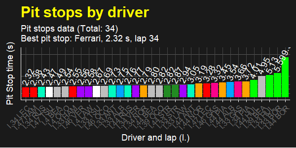

```r
pitplot_pitdata
```

Finally, if you want a fun text for your plot, run the ‘pitart()’ function in the title_text argument. For example,

```r
pitplot(pitdata,1,title_text = paste0(pitart(3),"    Pit Stop data")) -> pitplot_pitdata_title_edit
```

```
#> Processing...
#>   O    _________    O
#> /|\>  _\=..o..=/_  </|\
#>  / \ |_|-// \\-|_| / \
#>   O    _________    O
#> /|\>  _\=..o..=/_  </|\
#>  / \ |_|-// \\-|_| / \
```

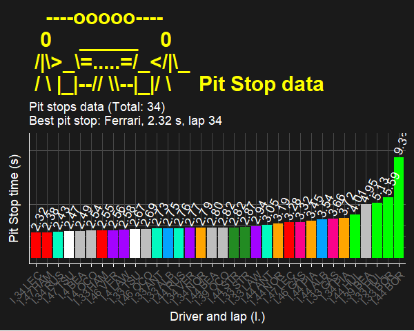

```r
pitplot_pitdata_title_edit
```

# Citations

This package makes extensive use of **‘dplyr’** for data manipulation and **‘ggplot2’** for plotting the data. **‘httr’** and **‘jsonlite’** also to access my repository data. **‘f1dataR’** has inspired me to create this package as a complement.

To cite this package in publications use:, Jordán-Soria J (2025). *f1pits: F1 Pit Stop Datasets*. Formula 1 pit stop data. The package provides information on teams and drivers across seasons (2019 or higher). It also includes a function to visualize pit stop performance., https://github.com/Jordan-Soria/f1pits.

A BibTeX entry for LaTeX users is

@Manual{, title = {f1pits: F1 Pit Stop Datasets}, author = {José Jordán-Soria}, year = {2025}, note = {Formula 1 pit stop data. The package provides information on teams and drivers across seasons (2019 or higher). It also includes a function to visualize pit stop performance.}, url = {https://github.com/Jordan-Soria/f1pits}, },